# UArizona EDSci Fellowship

Summer professional development workshop: Sample activity in R

Adriana Picoral

June 11, 2021

# Get the data

Access the [CDC page](https://data.cdc.gov/stories/s/cnd2-a6zw)

Download [the data from the CDC website](https://data.cdc.gov/Vaccinations/Vaccine-Hesitancy-for-COVID-19-County-and-local-es/q9mh-h2tw).

Create a folder somewhere in your computer for your R project. Create a `data` folder inside the project folder, and place the data file inside the `data` folder.

# Start new RStudio project

1. Go to `File` > `New Project`
2. Click on `Existing Directory`
3. `Browse...` to where your project folder is
4. Click `Create Project` to open your project session

# Load library

We will be using `tidyverse` for this lesson. Remember to run `install.packages("tidyverse")` if you don’t have this package installed yet.

```r
library(tidyverse)
```

We are now ready to read data in.

# Read data in

Use `read_csv()` with the path to your data file to read the data in.

```r
vaccine_hesitancy <- read_csv("data/Vaccine_Hesitancy_for_COVID-19__County_and_local_estimates.csv")
```

You can inspect your data using `view(vaccine_hesitancy)`.

# Data analysis

## Percent of adults in Arizona that are fully vaccinated

> What percentage of the adult population in Arizona are fully vaccinated against COVID-19? Which Arizona county has the highest percentage of adult population vaccinated? Which county has the lowest percentage?

Steps:

1. start with the dataframe object `vaccine_hesitancy` and then (remember that `and then` is how we read the pipe, or `%>%`)
2. filter to keep State equals (`==`) “ARIZONA” (state names are all capitalized) and then
3. select the columns of interest to display to answer the questions above, which in this case are the columns `County Name` and `Percent adults fully vaccinated against COVID-19`. Remember to use backtick (') around column names that contain space. And then …
4. arrange by `Percent adults fully vaccinated against COVID-19` to get an orderd results tables from the lowest to the highest percentage

```r
vaccine_hesitancy %>%
  filter(State == "ARIZONA") %>%
  select(`County Name`, `Percent adults fully vaccinated against COVID-19`) %>%
  arrange(`Percent adults fully vaccinated against COVID-19`)
```

```
## # A tibble: 15 x 2
##    `County Name`              `Percent adults fully vaccinated against COVID-19`
##    <chr>                                                                   <dbl>
##  1 Mohave County, Arizona                                                  0.255
##  2 Yavapai County, Arizona                                                 0.337
##  3 Pinal County, Arizona                                                   0.34
##  4 La Paz County, Arizona                                                  0.365
##  5 Maricopa County, Arizona                                                0.368
##  6 Greenlee County, Arizona                                                0.388
##  7 Cochise County, Arizona                                                 0.405
##  8 Yuma County, Arizona                                                    0.449
##  9 Gila County, Arizona                                                    0.479
## 10 Pima County, Arizona                                                    0.479
## 11 Graham County, Arizona                                                  0.486
## 12 Navajo County, Arizona                                                  0.492
## 13 Coconino County, Arizona                                                0.56
## 14 Apache County, Arizona                                                  0.624
## 15 Santa Cruz County, Arizona                                              0.698
```

We can get measures of centrality (e.g., mean) and variability (e.g., standard deviation) in the state of Arizona by using `summarize()` with functions like `mean()` and `sd()`.

```r
vaccine_hesitancy %>%
  filter(State == "ARIZONA") %>%
  summarize(mean_percent = mean(`Percent adults fully vaccinated against COVID-19`),
            sd_percent = sd(`Percent adults fully vaccinated against COVID-19`))
```

```
## # A tibble: 1 x 2
##   mean_percent sd_percent
##          <dbl>      <dbl>
## 1        0.448      0.117
```

> Overall, on average, 44.8% of the adult population in Arizona across different counties are fully vaccinated (11 percent points for standard deviation).

## Hesitancy in getting the COVID-19 vaccine in Arizona

To understand how `hesitancy` is defined, here are the [descriptions for the three types found on the CDC website](https://data.cdc.gov/stories/s/cnd2-a6zw):

"We use three definitions to capture the strength of hesitancy to receive a vaccine.

- Strongly hesitant: includes only survey responses indicating that they would *definitely not* receive a COVID-19 vaccine when available.
- Hesitant: includes survey responses indicating that they would “probably not” or *definitely not* receive a COVID-19 vaccine when available.
- Hesitant or unsure: includes survey responses indicating that they would *probably not* or *unsure* or *definitely not* receive a COVID-19 vaccine when available."

We will follow these steps:

1. start with `vaccine_hesitancy` and then
2. filter the data to keep State that is equal to “ARIZONA”
3. select the columns `County Name`, `Estimated hesitant`, `Estimated hesitant or unsure`, and `Estimated strongly hesitant`

```r
vaccine_hesitancy %>%
  filter(State == "ARIZONA") %>%
  select(`County Name`,
         `Estimated hesitant`,
         `Estimated hesitant or unsure`,
         `Estimated strongly hesitant`)
```

| County Name | Estimated hesitant | Estimated hesitant or unsure | Estimated strongly hesitant |
| --- | --- | --- | --- |
| Pinal County, Arizona | 0.1422 | 0.2077 | 0.0877 |
| Mohave County, Arizona | 0.1330 | 0.1919 | 0.0825 |
| Apache County, Arizona | 0.2114 | 0.2823 | 0.1598 |
| La Paz County, Arizona | 0.1330 | 0.1919 | 0.0825 |
| Gila County, Arizona | 0.1478 | 0.2114 | 0.0969 |
| Santa Cruz County, Arizona | 0.1290 | 0.1904 | 0.0764 |
| Greenlee County, Arizona | 0.1478 | 0.2114 | 0.0969 |
| Cochise County, Arizona | 0.1290 | 0.1904 | 0.0764 |
| Yuma County, Arizona | 0.1311 | 0.1992 | 0.0770 |
| Navajo County, Arizona | 0.2114 | 0.2823 | 0.1598 |
| Coconino County, Arizona | 0.1539 | 0.2099 | 0.1022 |
| Yavapai County, Arizona | 0.1211 | 0.1710 | 0.0746 |
| Maricopa County, Arizona | 0.1219 | 0.1800 | 0.0710 |
| Pima County, Arizona | 0.1228 | 0.1809 | 0.0723 |
| Graham County, Arizona | 0.1478 | 0.2114 | 0.0969 |

> REFLECTION: How can you explain the differences in hesitancy for getting the COVID-19 vaccine? – remember to based your interpretation on evidence, and not on your opinion (and biases).

## Relationship between level of concern and vaccination rates in adults

> What is the relationship between level of concern and vaccination rates in adults across the United States?

### Understand variables

To answer the question for this session, we will be using the `CVAC Level Of Concern` variable. Let’s first take a look at how many observations we have for each unique value in this categorical variable.

```r
vaccine_hesitancy %>%
  count(`CVAC Level Of Concern`)
```

```
## # A tibble: 5 x 2
##   `CVAC Level Of Concern`     n
##   <chr>                   <int>
## 1 High Concern              628
## 2 Low Concern               628
## 3 Moderate Concern          628
## 4 Very High Concern         629
## 5 Very Low Concern          629
```

We can use `group_by()` with `summarize()` to get the `mean` estimated hisitancy per level of concern. We follow these steps:

1. start with vaccine_hesitancy and then
2. group by `CVAC Level Of Concern` and then
3. summarize the mean of `Estimated hesitant or unsure` and then
4. arrange by your newly created mean variable (created inside `summarize` in the previous step)

```r
vaccine_hesitancy %>%
  group_by(`CVAC Level Of Concern`) %>%
  summarize(mean_hesitancy = mean(`Estimated hesitant or unsure`)) %>%
  arrange(mean_hesitancy)
```

```
## # A tibble: 5 x 2
##   `CVAC Level Of Concern` mean_hesitancy
##   <chr>                            <dbl>
## 1 Very Low Concern                 0.180
## 2 Low Concern                      0.187
## 3 Moderate Concern                 0.199
## 4 High Concern                     0.219
## 5 Very High Concern                0.228
```

> It seems that `Very Low Concern` has the lowest hesitancy (or unsureness) percentace, while `Very High Concern` has the highest hesitancy (or unsureness) percentage.

### Get summary table

Here’s a reminder of our data question:

> What is the relationship between level of concern and vaccination rates in adults across the United States?

We can answer this question by creating a table very similar to the last table we created, by grouping by `CVAC Level Of Concern` and then calculating not only the mean of `Estimated hesitant or unsure` but also the mean of `Percent adults fully vaccinated against COVID-19`.

Here are our steps:

1. start with vaccine_hesitancy and then
2. group by `CVAC Level Of Concern` and then
3. summarize the mean of `Estimated hesitant or unsure` and the mean of `Percent adults fully vaccinated against COVID-19` (make sure you use `ra.rm = TRUE` inside `mean()` to ignore missing values) and then
4. arrange by your newly created mean variable (created inside `summarize` in the previous step)

```r
vaccine_hesitancy %>%
  group_by(`CVAC Level Of Concern`) %>%
  summarize(mean_hesitancy = mean(`Estimated hesitant or unsure`),
            mean_vacc_rate = mean(`Percent adults fully vaccinated against COVID-19`, na.rm = TRUE)) %>%
  arrange(mean_hesitancy)
```

```
## # A tibble: 5 x 3
##   `CVAC Level Of Concern` mean_hesitancy mean_vacc_rate
##   <chr>                            <dbl>          <dbl>
## 1 Very Low Concern                 0.180          0.414
## 2 Low Concern                      0.187          0.367
## 3 Moderate Concern                 0.199          0.339
## 4 High Concern                     0.219          0.317
## 5 Very High Concern                0.228          0.270
```

### Visualize raw data

Another way to get to the relationship between `Estimated hesitant or unsure` and `Percent adults fully vaccinated against COVID-19` is by plotting a scatterplot of these two numeric variables (map one variable to `x` and another to `y`). We can add a linear regression line with `geom_smooth()`.

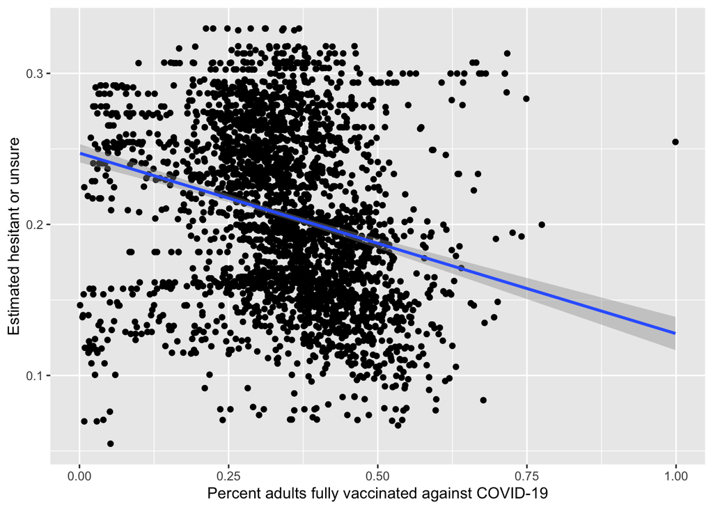

```r
vaccine_hesitancy %>%
  ggplot(aes(x = `Percent adults fully vaccinated against COVID-19`,
             y = `Estimated hesitant or unsure`)) +
  geom_point() +
  geom_smooth(method = "lm")
```

> How would you interpret the plot above? What is the relationship between `Estimated hesitant or unsure` and `Percent adults fully vaccinated against COVID-19`?

### Visualize summarized data

We can plot results of our `group_by` + `summarize` that we did before, adding `State` to our `group_by` to get a summarization of the mean of `Percent adults fully vaccinated against COVID-19` by different `CVAC Level Of Concern` and `State`.

Our steps here are:

1. start with `vaccine_hesitancy` and then
2. group by `State` and `CVAC Level Of Concern` and then
3. summarize the mean of `Percent adults fully vaccinated against COVID-19` (ignoring missing data) and then
4. use mutate to rearrange the levels in the categorical variable `CVAC Level Of Concern` so these display in the correct order and then
5. start a plot by mapping `CVAC Level Of Concern` to y and the mean created in summarize() to x, add
6. a column geometrics with geom_col, add
7. a facet by `State` (optionally set number of facet columns to 3), and add
8. a label to x that is easy to understand

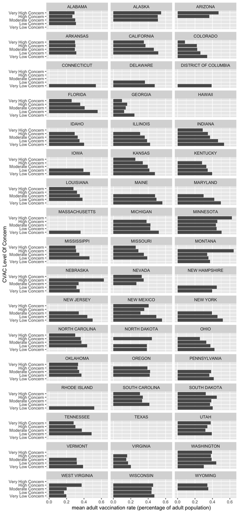

```r
vaccine_hesitancy %>%
  group_by(State, `CVAC Level Of Concern`) %>%
  summarize(mean_vacc_rate = mean(`Percent adults fully vaccinated against COVID-19`, na.rm = TRUE)) %>%
  mutate(`CVAC Level Of Concern` = factor(`CVAC Level Of Concern`,
                                          levels = c("Very Low Concern",
                                                     "Low Concern",
                                                     "Moderate Concern",
                                                     "High Concern",
                                                     "Very High Concern"))) %>%
  ggplot(aes(y = `CVAC Level Of Concern`,
             x = mean_vacc_rate)) +
  geom_col() +
  facet_wrap(~State, ncol = 3) +
  labs(x = "mean adult vaccination rate (percentage of adult population)")
```

> REFLECTION: How does Arizona compare to other states in terms of the COVID-19 vaccine level of concern? How would you explain the missing data for some states?

# How are the data reported on the media?

Read how the data collected by the CDC have been analyzed and reported on the media. How does it compare to your findings?

- [ABC News: 3 things scientists have learned about vaccine hesitancy: Analysis](https://abcnews.go.com/Health/things-scientists-learned-vaccine-hesitancy-analysis/story?id=77127290)